# Functional_Diversity

Maggie Klope

10/18/2020

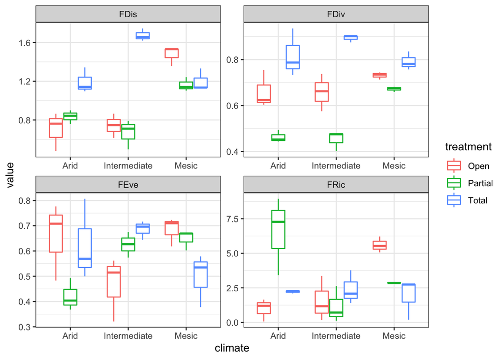

```r
FD_all %>%
  pivot_longer(cols = c(FRic, FEve:FDis),
               names_to = "FD",
               values_to = "value") %>%
  ggplot(aes(x = climate, y = value, color = treatment)) +
  geom_boxplot() +
  theme_bw() +
  facet_wrap(~FD, scales = "free")
```

```r
# ggsave("Functional_Diversity_Barchart.png", path = "~/github/Tejon_Functional_Traits/Figures")
```

### Models

#### FRic

- averaged over treatment, there is a sig difference between Arid-Int and Int-Mesic, but not Arid-Mesic
- averaged over climate, there is not sig difference between treatments
- Arid
  - Arid Partial > Arid Open
  - Arid Partial > Arid Total
  - No difference between Arid Open and Arid Total
- Int
  - No difference between herbivore treatments at int
- Mesic
  - Mesic Open > Mesic Total
- Open
  - Mesic Open > Arid Open
  - Mesic Open > Int Open
  - no diff between arid open and int open
- Partial
  - Arid Partial > Intermediate Partial
  - Arid Partial > Mesic Partial
  - No difference between int partial and mesic partial
- Total -No difference between climates for total exclosure

```r
FRic <- glm(data = FD_all, FRic ~ climate * treatment, family = gaussian, na.action = na.fail)
dredge(FRic) #best model: FRic ~ climate * treatment
```

```
## Fixed term is "(Intercept)"
```

```
## Global model call: glm(formula = FRic ~ climate * treatment, family = gaussian,
##     data = FD_all, na.action = na.fail)
## ---
## Model selection table
##    (Int) clm trt clm:trt df  logLik  AICc delta weight
## 8 0.9732   +   +       + 10 -41.472 116.7  0.00  0.927
## 1 2.8040                  2 -59.149 122.8  6.10  0.044
## 2 3.2450   +              4 -57.290 124.4  7.70  0.020
## 3 2.7150       +          4 -58.238 126.3  9.60  0.008
## 4 3.1560   +   +          6 -56.240 128.7 11.99  0.002
## Models ranked by AICc(x)
```

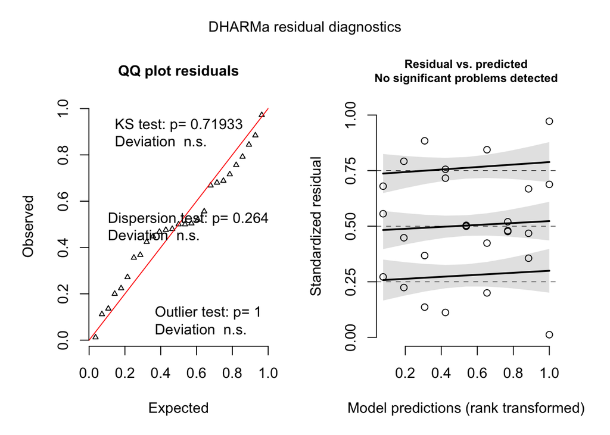

```
## Object of Class DHARMa with simulated residuals based on 250 simulations with refit = FALSE . See ?DHARMa::simulateResiduals for help.
##
## Scaled residual values: 0.272 0.556 0.68 0.688 0.972 0.012 0.5 0.504 0.5 0.368 0.884 0.136 0.448 0.792 0.224 0.844 0.2 0.424 0.668 0.356 ...
```

```r
# does data fit model?
simulateResiduals(FRic, plot=T) # looks ok
```

```r
shapiro.test(residuals(FRic)) # residuals are normal
```

```
##
##  Shapiro-Wilk normality test
##
## data:  residuals(FRic)
## W = 0.97436, p-value = 0.7192
```

```r
# significant pairs
FRic_sig_pairs <-  as.data.frame(pairs(emmeans(FRic, ~ climate * treatment)))%>%
  filter(p.value <= 0.05)

# all pairwise comparisons
emmeans(FRic, pairwise ~ climate)
```

```
## NOTE: Results may be misleading due to involvement in interactions
```

```
## $emmeans
##  climate      emmean    SE  df asymp.LCL asymp.UCL
##  Arid           3.25 0.459 Inf     2.346      4.14
##  Intermediate   1.71 0.459 Inf     0.814      2.61
##  Mesic          3.45 0.459 Inf     2.554      4.35
##
## Results are averaged over the levels of: treatment
## Confidence level used: 0.95
##
## $contrasts
##  contrast             estimate    SE  df z.ratio p.value
##  Arid - Intermediate     1.532 0.649 Inf  2.360  0.0480
##  Arid - Mesic           -0.208 0.649 Inf -0.321  0.9447
##  Intermediate - Mesic   -1.740 0.649 Inf -2.681  0.0201
##
## Results are averaged over the levels of: treatment
## P value adjustment: tukey method for comparing a family of 3 estimates
```

```r
emmeans(FRic, pairwise ~ treatment)
```

```
## NOTE: Results may be misleading due to involvement in interactions
```

```
## $emmeans
##  treatment emmean    SE  df asymp.LCL asymp.UCL
##  Open        2.71 0.459 Inf      1.82      3.61
##  Partial     3.52 0.459 Inf      2.62      4.42
##  Total       2.18 0.459 Inf      1.28      3.08
##
## Results are averaged over the levels of: climate
## Confidence level used: 0.95
##
## $contrasts
##  contrast        estimate    SE  df z.ratio p.value
##  Open - Partial    -0.807 0.649 Inf -1.243  0.4280
##  Open - Total       0.538 0.649 Inf  0.829  0.6851
##  Partial - Total    1.344 0.649 Inf  2.071  0.0958
##
## Results are averaged over the levels of: climate
## P value adjustment: tukey method for comparing a family of 3 estimates
```

```r
# emmeans(FRic, pairwise ~ climate * treatment)
emmeans(FRic, pairwise ~ climate | treatment)
```

```
## $emmeans
## treatment = Open:
##  climate      emmean    SE  df asymp.LCL asymp.UCL
##  Arid          0.973 0.795 Inf   -0.5848      2.53
##  Intermediate  1.568 0.795 Inf    0.0104      3.13
##  Mesic         5.602 0.795 Inf    4.0440      7.16
##
## treatment = Partial:
##  climate      emmean    SE  df asymp.LCL asymp.UCL
##  Arid          6.545 0.795 Inf    4.9865      8.10
##  Intermediate  1.152 0.795 Inf   -0.4059      2.71
##  Mesic         2.866 0.795 Inf    1.3085      4.42
##
## treatment = Total:
##  climate      emmean    SE  df asymp.LCL asymp.UCL
##  Arid          2.218 0.795 Inf    0.6598      3.78
##  Intermediate  2.420 0.795 Inf    0.8617      3.98
##  Mesic         1.892 0.795 Inf    0.3344      3.45
##
## Confidence level used: 0.95
##
## $contrasts
## treatment = Open:
##  contrast             estimate   SE  df z.ratio p.value
##  Arid - Intermediate    -0.595 1.12 Inf -0.529  0.8569
##  Arid - Mesic           -4.629 1.12 Inf -4.118  0.0001
##  Intermediate - Mesic   -4.034 1.12 Inf -3.588  0.0010
##
## treatment = Partial:
##  contrast             estimate   SE  df z.ratio p.value
##  Arid - Intermediate     5.392 1.12 Inf  4.797  <.0001
##  Arid - Mesic            3.678 1.12 Inf  3.272  0.0031
##  Intermediate - Mesic   -1.714 1.12 Inf -1.525  0.2791
##
## treatment = Total:
##  contrast             estimate   SE  df z.ratio p.value
##  Arid - Intermediate    -0.202 1.12 Inf -0.180  0.9824
##  Arid - Mesic            0.325 1.12 Inf  0.289  0.9549
##  Intermediate - Mesic    0.527 1.12 Inf  0.469  0.8858
##
## P value adjustment: tukey method for comparing a family of 3 estimates
```